# QGAM modelling of extreme rainfall in Switzerland: solution

```r
library(mgcViz);
library(gamair);
data(swer)

form <- exra ~ s(nao) + s(elevation) + climate.region + s(E, N) + s(year, k = 5)
fit <- qgamV(form, data = swer, qu = 0.5)
```

```
## Estimating learning rate. Each dot corresponds to a loss evaluation.
## qu = 0.5...............done
```

```r
summary(fit)
```

```
##
## Family: elf
## Link function: identity
##
## Formula:
## exra ~ s(nao) + s(elevation) + climate.region + s(E, N) + s(year,
##     k = 5)
##
## Parametric coefficients:
##                                            Estimate Std. Error z value
## (Intercept)                                  69.488      3.933  17.670
## climate.regionCentral Alpine north slope    -25.306      4.977  -5.084
## climate.regionCentral plateau               -24.225      5.686  -4.260
## climate.regionEastern Alpine north slope    -15.011      5.950  -2.523
## climate.regionEastern Jura                  -21.495      6.358  -3.381
## climate.regionEngadine                      -18.976      3.797  -4.997
## climate.regionNorth-eastern plateau         -14.585      6.341  -2.300
## climate.regionNorthern and central Grisons  -15.968      4.399  -3.630
## climate.regionValais                        -30.228      5.298  -5.705
## climate.regionWestern Alpine north slope    -29.827      5.071  -5.882
## climate.regionWestern Jura                  -21.164      6.833  -3.097
## climate.regionWestern plateau               -21.765      6.399  -3.401
##                                            Pr(>|z|)
## (Intercept)                                 < 2e-16 ***
## climate.regionCentral Alpine north slope   3.69e-07 ***
## climate.regionCentral plateau              2.04e-05 ***
## climate.regionEastern Alpine north slope   0.011640 *
## climate.regionEastern Jura                 0.000723 ***
## climate.regionEngadine                     5.82e-07 ***
## climate.regionNorth-eastern plateau        0.021431 *
## climate.regionNorthern and central Grisons 0.000283 ***
## climate.regionValais                       1.16e-08 ***
## climate.regionWestern Alpine north slope   4.06e-09 ***
## climate.regionWestern Jura                 0.001952 **
## climate.regionWestern plateau              0.000671 ***
## ---
## Signif. codes:  0 '***' 0.001 '**' 0.01 '*' 0.05 '.' 0.1 ' ' 1
##
## Approximate significance of smooth terms:
##                 edf Ref.df Chi.sq  p-value
## s(nao)        6.278  7.352  25.81 0.000753 ***
## s(elevation)  6.031  6.966  82.76 5.63e-15 ***
## s(E,N)       23.128 26.540 263.31  < 2e-16 ***
## s(year)       1.006  1.012   0.00 0.997441
## ---
## Signif. codes:  0 '***' 0.001 '**' 0.01 '*' 0.05 '.' 0.1 ' ' 1
##
## R-sq.(adj) =  0.484   Deviance explained = 36.5%
## -REML = 9204.4  Scale est. = 1         n = 2196
```

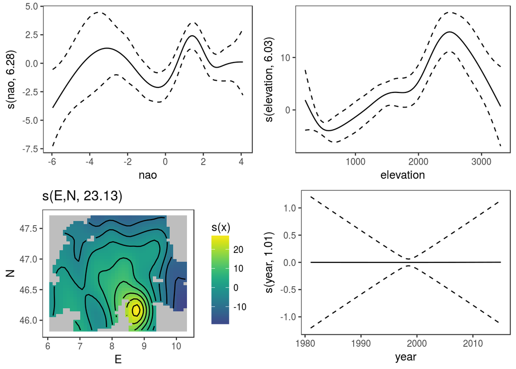

```r
print(plot(fit), pages = 1)
```

2. Fit a smooth trend for each climate region:

```r
fit2 <- qgamV(exra ~ s(nao) + s(elevation) +
                     s(year, climate.region, bs = "fs", k = 5) + s(E, N),
                     data = swer, qu = 0.5)
```

```
## Estimating learning rate. Each dot corresponds to a loss evaluation.
## qu = 0.5..........done
```

```r
summary(fit2)
```

```
##
## Family: elf
## Link function: identity
##
## Formula:
## exra ~ s(nao) + s(elevation) + s(year, climate.region, bs = "fs",
##     k = 5) + s(E, N)
##
## Parametric coefficients:
##             Estimate Std. Error z value Pr(>|z|)
## (Intercept)   49.784      1.828   27.24   <2e-16 ***
## ---
## Signif. codes:  0 '***' 0.001 '**' 0.01 '*' 0.05 '.' 0.1 ' ' 1
##
## Approximate significance of smooth terms:
##                           edf Ref.df Chi.sq  p-value
## s(nao)                  6.414  7.465  27.79 0.000366 ***
## s(elevation)            5.930  6.843  94.68  < 2e-16 ***
## s(year,climate.region) 14.803 59.000  55.94 2.91e-11 ***
## s(E,N)                 24.888 27.371 297.46  < 2e-16 ***
## ---
## Signif. codes:  0 '***' 0.001 '**' 0.01 '*' 0.05 '.' 0.1 ' ' 1
##
## R-sq.(adj) =  0.487   Deviance explained = 36.8%
## -REML =   9231  Scale est. = 1         n = 2196
```

```r
AIC(fit) - AIC(fit2)
```

```
## [1] 30.11005
```

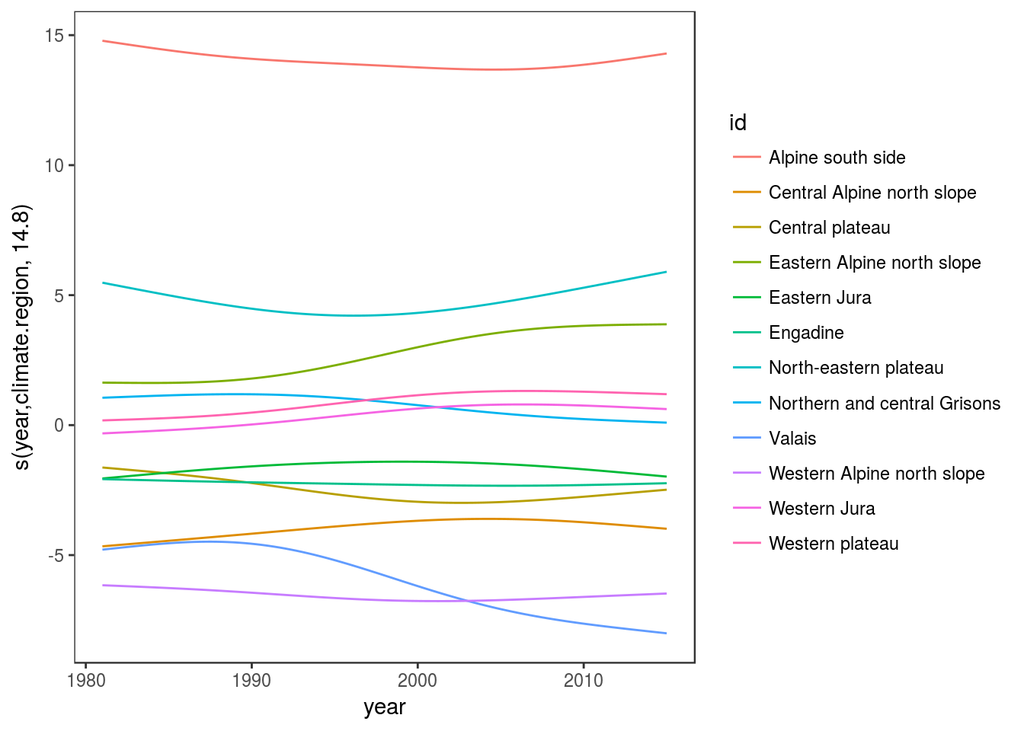

```r
plot(sm(fit2, 3)) + l_fitLine(alpha = 1)
```

The effect of year-by-region is using relatively few degrees of freedom (`edf`), there might have been a slight decrease in rainfall in Valais, for instance.

3. Fit a 3D spatio-temporal tensor product effect:

```r
fit <- qgamV(exra ~ s(nao) + s(elevation) + climate.region +
                    te(E, N, year, d = c(2, 1), k = c(20, 5)),
                    data = swer, qu = 0.5)
```

```
## Estimating learning rate. Each dot corresponds to a loss evaluation.
## qu = 0.5.............done
```

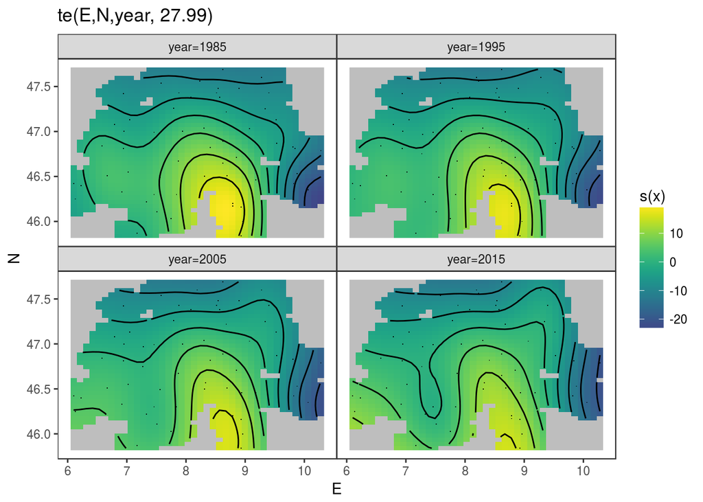

```r
plotSlice(x = sm(fit, 3),
          fix = list("year" = c(1985, 1995, 2005, 2015))) + l_fitRaster() +
          l_fitContour() + l_points()
```

There doesn’t seem to be much change in the precipication pattern, maybe there is a decrease of rainfall levels in the South East (in the Canton of Ticino).

4. We plot two slice through time using `rgl`:

```r
# These will not appear in the html output
plotRGL(x = sm(fit, 3), fix = c("year" = 1985), residuals = TRUE)
open3d()
```

```
## glX
##   2
```

```r
plotRGL(x = sm(fit, 3), fix = c("year" = 2015), residuals = TRUE)
rgl.close()
rgl.close()
```

5. Remove the tensor effect w.r.t. time and fit the model to several quantiles:

```r
fitM <- mqgamV(exra ~ s(nao) + s(elevation) + climate.region + s(E, N) + s(year, k = 5),
               data = swer, qu = seq(0.1, 0.9, length.out = 9) )
```

```
## Estimating learning rate. Each dot corresponds to a loss evaluation.
## qu = 0.5...............done
## qu = 0.4..........done
## qu = 0.6............done
## qu = 0.3..........done
## qu = 0.7................done
## qu = 0.2..........done
## qu = 0.8..........done
## qu = 0.1..................done
## qu = 0.9.....................done
```

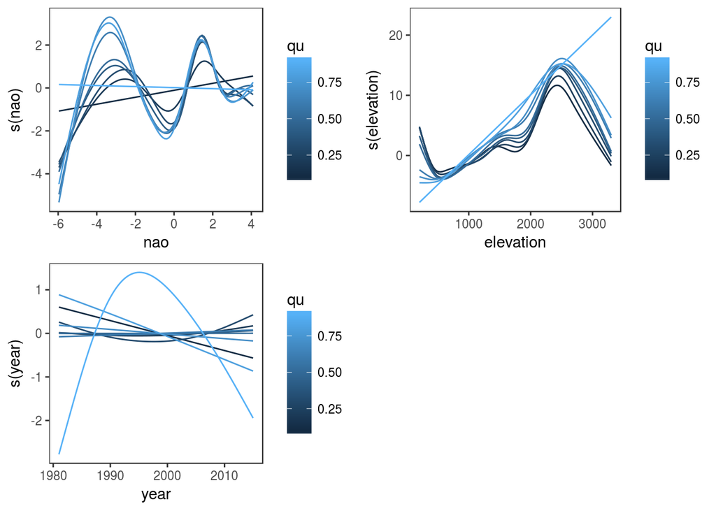

```r
# Plot univariate smooths
print(plot(fitM, select = c(1, 2, 4)), pages = 1)
```

```r
summary(fitM[[9]])
```

```
##
## Family: elf
## Link function: identity
##
## Formula:
## exra ~ s(nao) + s(elevation) + climate.region + s(E, N) + s(year,
##     k = 5)
##
## Parametric coefficients:
##                                            Estimate Std. Error z value
## (Intercept)                                 100.434      8.146  12.329
## climate.regionCentral Alpine north slope    -25.020      9.818  -2.548
## climate.regionCentral plateau               -31.412     11.597  -2.709
## climate.regionEastern Alpine north slope    -13.062     12.941  -1.009
## climate.regionEastern Jura                  -32.055     13.336  -2.404
## climate.regionEngadine                      -23.633      7.268  -3.252
## climate.regionNorth-eastern plateau         -34.748     13.676  -2.541
## climate.regionNorthern and central Grisons  -20.415      8.701  -2.346
## climate.regionValais                        -39.460     11.234  -3.513
## climate.regionWestern Alpine north slope    -35.022      9.987  -3.507
## climate.regionWestern Jura                  -25.213     14.648  -1.721
## climate.regionWestern plateau               -24.630     13.349  -1.845
##                                            Pr(>|z|)
## (Intercept)                                 < 2e-16 ***
## climate.regionCentral Alpine north slope   0.010824 *
## climate.regionCentral plateau              0.006756 **
## climate.regionEastern Alpine north slope   0.312823
## climate.regionEastern Jura                 0.016229 *
## climate.regionEngadine                     0.001147 **
## climate.regionNorth-eastern plateau        0.011059 *
## climate.regionNorthern and central Grisons 0.018961 *
## climate.regionValais                       0.000444 ***
## climate.regionWestern Alpine north slope   0.000453 ***
## climate.regionWestern Jura                 0.085194 .
## climate.regionWestern plateau              0.065028 .
## ---
## Signif. codes:  0 '***' 0.001 '**' 0.01 '*' 0.05 '.' 0.1 ' ' 1
##
## Approximate significance of smooth terms:
##                 edf Ref.df  Chi.sq  p-value
## s(nao)        1.001  1.003   0.004    0.951
## s(elevation)  1.004  1.008  24.382 8.68e-07 ***
## s(E,N)       21.502 25.401 180.675  < 2e-16 ***
## s(year)       2.011  2.464   2.305    0.295
## ---
## Signif. codes:  0 '***' 0.001 '**' 0.01 '*' 0.05 '.' 0.1 ' ' 1
##
## R-sq.(adj) =  0.388   Deviance explained = 63.3%
## -REML =  11205  Scale est. = 1         n = 2196
```

It seems that the effect of `NAO` is very weak for extreme quantiles, however the reason for this might simply be that the data is quite sparse in the tails. Also, the effect of `year` seems to be highly non-linear for quantile 0.9, but `summary` shows that this effect is not significant.

We can also plot the spatial effect:

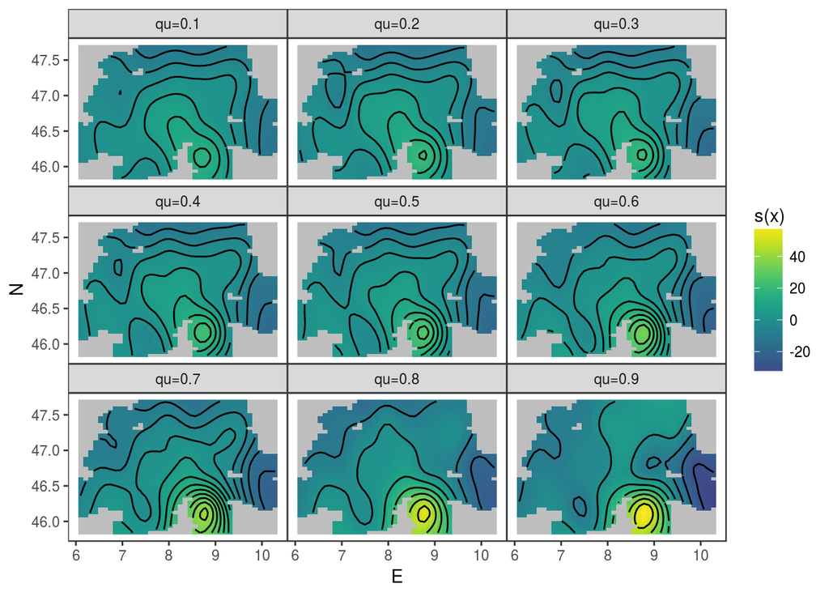

```r
print(plot(fitM, select = 3), pages = 1)
```

Finally we can see how the climate region effect changes depending on the quantile of interest:

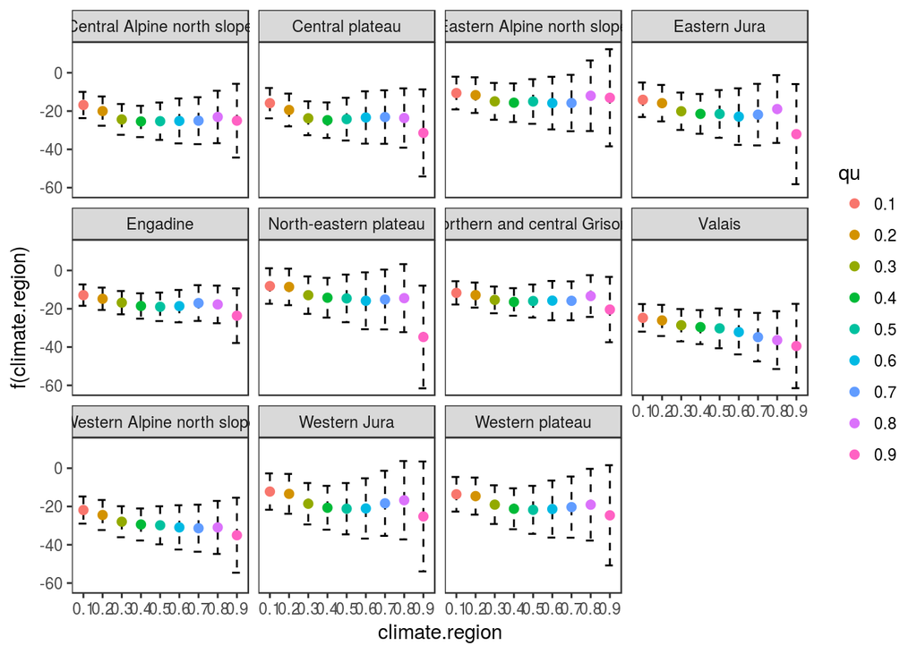

```r
print(plot(fitM, select = 5), pages = 1)
```